# Phase 2: Model Planning and Building

Brendan Allen

#### [Home](https://ballen2024.github.io/DataScience/index.html)

#### [Phase 1: Discovery and Data Preparation](https://ballen2024.github.io/DataScience/deliverable1.html)

#### [Phase 2: Model Planning and Building](https://ballen2024.github.io/DataScience/deliverable2.html)

#### [Phase 3: Results and Operationalization](https://ballen2024.github.io/DataScience/deliverable3.html)

### Getting Started

**First we want to import any necessary libraries we will be using.**

**Note: Uncomment the install lines if you haven’t yet installed these packages**

```r
# install.packages("tidyr")
# install.packages("dplyr")
# install.packages("devtools")
# devtools::install_github("stefanedwards/lemon")
# install.packages("scales")
# install.packages("tidyverse")
# install.packages("knitr")
# install.packages("stringr")
# install.packages("caret")

suppressMessages(library(tidyr))
suppressMessages(library(dplyr))
suppressMessages(library(lemon))
suppressMessages(library(scales))
suppressMessages(library(tidyverse))
suppressMessages(library(knitr))
suppressMessages(library(stringr))
suppressMessages(library(caret))
suppressMessages(library(baseballr))
knit_print.data.frame <- lemon_print
```

**We will want to import all of our work from [Phase 1](https://ballen2024.github.io/DataScience/deliverable1.html) as well.**

```r
purl("deliverable1.Rmd", output = "deliverable1.r")
source("deliverable1.r")
```

### Looking at the Data

The data source **Baseball Savant** is an MLB affiliate that collects baseball statistics for major league games. The initial data set here `foul_balls` includes **906** observations with **7** variables. The dataset was used originally to observe where the most dangerous foul balls land, which is discussed in depth in [this story](https://fivethirtyeight.com/features/we-watched-906-foul-balls-to-find-out-where-the-most-dangerous-ones-land/). Our `launch_data` set was also collected from this source. I also used [**Baseball Reference**](https://www.baseball-reference.com/leagues/MLB/2016-standings.shtml) to gather data on standings for the 2016 MLB season. Just in my initial investigation, there appeared to be some `NA` data points, so we’ll have to clean the data up. I also noticed that there is some inconsistent or inappropriate type formatting, so we’ll have to clean that up as well.

#### Here is an overview of each dataset

##### `foul_balls`

- **`matchup`**
  - The two teams that played. Formatted like `Atlanta Braves vs New York Mets`. In order to have a merge point for this set and the previous set, I am going to make a lookup table with the team names and their corresponding three character codes.
- **`date`**
  - Date of the most foul-heavy day at each stadium. Formatted like `yyyy-mm-dd`.
- **`hit_type`**
  - Fly, grounder, line drive, pop up or batter hit self. Formated as a string.
- **`velocity`**
  - Recorded exit velocity of each hit – blank if not provided. Formatted as a double
- **`predicted_zone`**
  - The zone we predicted the foul ball would land in by gauging angles. Formatted as a factor.
- **`camera_zone`**
  - The zone that the foul ball landed in, confirmed by footage. Formatted as a factor.
- **`used_zone`**
  - The zone used for analysis. Formatted as a factor.

##### `launch_data`

- **`date`**
  - Date of the game where this hit was recorded Formatted like `yyyy-mm-dd`.
- **`field`**
  - Field where the game was played. Formatted as string.
- **`home`**
  - Name of home team’s 3 character abbreviation. Formatted as a string.
- **`away`**
  - Name of away team’s 3 character abbreviation. Formatted as a string.
- **`velocity`**
  - Exit velocity of the ball hit. Formatted as a double.
- **`angle`**
  - Angle of the ball hit in degrees. Formatted as a double.

##### `standings`

- **`rank`**
  - Team rank overall. Formatted as a double
- **`team`**
  - Team name’s 3 character abbreviation
- **`games`**
  - Total number of games played. Formatted as a double.
- **`wins`**
  - Total number of games won. Formatted as a double.
- **`losses`**
  - Total number of games lost. Formatted as a double.
- **`run_diff`**
  - Run differential (average runs scored - average runs allowed). Formatted as a double.

**Let’s read in our new data on foul balls**

```r
foul_balls <- suppressMessages(read_csv("https://raw.githubusercontent.com/fivethirtyeight/data/master/foul-balls/foul-balls.csv"))
launch_data <- suppressMessages(read_csv("./savant_data.csv"))
standings <- suppressMessages(read_csv("./standings.csv"))
```

**We’ll want to clean up our data now**

**Note: I had to manually change the name of the win-loss percentage column name in the `standings` dataset. In the original set is is name `W-L%`, but `R` doesn’t like the `%` since it is an operator, so I used a separate editor to change the name to `W_L_perc`**

```r
game_data <- game_data %>%
  filter(date >= 19900101) %>%
  rename(away=v_name, home=h_name)

foul_balls <- foul_balls %>%
  na.omit() %>%
  rename(date = game_date, hit_type = type_of_hit, velocity = exit_velocity)

launch_data <- launch_data %>%
  select(c(game_date, player_name, home_team, away_team, launch_speed, launch_angle)) %>%
  filter(launch_speed != "null", launch_angle != "null") %>%
  rename(date=game_date, field=player_name, home=home_team, away=away_team, velocty=launch_speed, angle=launch_angle)

standings <- standings %>%
  select(c(Rk, Tm, G, W, L, W_L_per, Rdiff)) %>%
  rename(rank=Rk, team=Tm, games=G, wins=W, losses=L, win_loss_percentage= W_L_per, run_diff=Rdiff) %>%
  na.omit()
```

**Now we need to standardize the formatting of our variables**

Here we converted the dates to an actual date format, made our foul ball zones factors, and our velocity and angle to a numeric type instead of a character.

```r
game_data$date <- as.character(game_data$date)
game_data$date <- as.Date(game_data$date, format="%Y%m%d")

foul_balls$predicted_zone <- as.factor(foul_balls$predicted_zone)
foul_balls$camera_zone <- as.factor(foul_balls$camera_zone)
foul_balls$used_zone <- as.factor(foul_balls$used_zone)

launch_data$velocty <- as.double(launch_data$velocty)
launch_data$angle <- as.double(launch_data$angle)
```

**To finalize cleaning our data, we need to do some work on the `matchup` column of our `foul_balls` data**

Specifically the matchup is formatted like `Atlanta Braves vs New York Mets`. We want to offer consistency with our other data sets, so we are going to split this `matchup` into `home` and `away`. We’ll need to make a lookup table though to convert the full team name into it’s 3 character abbreviation. I just created my own csv file for [this](https://github.com/ballen2024/ballen2024.github.io/blob/master/DataScience/teams.csv) in an editor, so we’ll have to load that.

```r
teams <- suppressMessages(read_csv("./teams.csv"))
```

Using regular expresions in `R`, we can split up the `matchup`’s into their `home` and `away` teams. We will want to grab everything in the string until we encounter “vs” or “VS” and store that as `away` team, since American convention holds that matchups are written as *away vs home*. We can throw away the “vs” or “VS” and then we can grab the second string and store it as the `home` team.

After a lot of trial an error to match the abbreviations to the full names in the `foul_balls` set, I finally realized the their was some unnoticed spaces at the front of the home teams and at the back of the away teams. This happened because of the way I used `str_split()`. I believe you could eat the whitespace, but I instead decided to add some spaces to the team names in the lookup table.

```r
split <- str_split(foul_balls$matchup, "(vs|VS)")
mat <- matrix(unlist(split), ncol=2, byrow=TRUE)
matchup <- as.data.frame(mat)
foul_balls$home <- as.character(matchup$V2)
foul_balls$away <- as.character(matchup$V1)

teams$space_front <- paste("", teams$full)
teams$space_back <- paste(teams$full, "")
foul_balls$home <- teams[match(foul_balls$home, teams$space_front), "abb"]
foul_balls$away <- teams[match(foul_balls$away, teams$space_back), "abb"]
```

**Here is a quick look at our data after being cleaned up**

#### `game_data`

| date | day | day_night | away | home | park_id | attendance | duration | v_score | h_score | v_hits | h_hits | v_homeruns | h_homeruns |
| --- | --- | --- | --- | --- | --- | --- | --- | --- | --- | --- | --- | --- | --- |
| 2000-03-29 | Wed | N | CHN | NYN | TOK01 | 55000 | 206 | 5 | 3 | 12 | 7 | 2 | 1 |
| 2000-03-30 | Thu | N | NYN | CHN | TOK01 | 55000 | 235 | 5 | 1 | 6 | 5 | 1 | 0 |
| 2000-04-03 | Mon | D | COL | ATL | ATL02 | 42255 | 134 | 0 | 2 | 6 | 7 | 0 | 2 |
| 2000-04-03 | Mon | D | MIL | CIN | CIN08 | 55596 | 111 | 3 | 3 | 7 | 5 | 0 | 1 |
| 2000-04-03 | Mon | N | SFN | FLO | MIA01 | 35101 | 166 | 4 | 6 | 10 | 12 | 1 | 0 |
| 2000-04-03 | Mon | N | LAN | MON | MON02 | 51249 | 157 | 10 | 4 | 9 | 9 | 2 | 2 |

#### `foul_balls`

| matchup | date | hit_type | velocity | predicted_zone | camera_zone | used_zone | home | away |
| --- | --- | --- | --- | --- | --- | --- | --- | --- |
| Seattle Mariners VS Minnesota Twins | 2019-05-18 | Fly | 78.8 | 1 | 1 | 1 | MIN | SEA |
| Seattle Mariners VS Minnesota Twins | 2019-05-18 | Fly | 76.0 | 5 | 5 | 5 | MIN | SEA |
| Seattle Mariners VS Minnesota Twins | 2019-05-18 | Line | 95.9 | 5 | 5 | 5 | MIN | SEA |
| Seattle Mariners VS Minnesota Twins | 2019-05-18 | Batter hits self | 69.9 | 1 | 1 | 1 | MIN | SEA |
| Seattle Mariners VS Minnesota Twins | 2019-05-18 | Line | 84.9 | 5 | 5 | 5 | MIN | SEA |
| Seattle Mariners VS Minnesota Twins | 2019-05-18 | Fly | 104.6 | 6 | 6 | 6 | MIN | SEA |

#### `launch_data`

| date | field | home | away | velocty | angle |
| --- | --- | --- | --- | --- | --- |
| 2016-09-01 | Citi Field | NYM | MIA | 72.5 | 54.7 |
| 2016-09-01 | Citi Field | NYM | MIA | 74.3 | 44.6 |
| 2016-09-01 | Target Field | MIN | CWS | 93.4 | -6.9 |
| 2016-09-01 | Citi Field | NYM | MIA | 77.8 | 21.7 |
| 2016-09-01 | Target Field | MIN | CWS | 68.3 | 27.4 |
| 2016-09-01 | Citi Field | NYM | MIA | 73.0 | 40.0 |

#### `standings`

| rank | team | games | wins | losses | win_loss_percentage | run_diff |
| --- | --- | --- | --- | --- | --- | --- |
| 1 | CHN | 162 | 103 | 58 | 0.640 | 1.6 |
| 2 | WAS | 162 | 95 | 67 | 0.586 | 0.9 |
| 3 | TEX | 162 | 95 | 67 | 0.586 | 0.0 |
| 4 | CLE | 161 | 94 | 67 | 0.584 | 0.6 |
| 5 | BOS | 162 | 93 | 69 | 0.574 | 1.1 |
| 6 | LAN | 162 | 91 | 71 | 0.562 | 0.5 |

#### `teams`

| full | abb | space_front | space_back |
| --- | --- | --- | --- |
| Arizona Diamondsbacks | ARI | Arizona Diamondsbacks | Arizona Diamondsbacks |
| Atlanta Braves | ATL | Atlanta Braves | Atlanta Braves |
| Baltimore Orioles | BAL | Baltimore Orioles | Baltimore Orioles |
| Boston Red Sox | BOS | Boston Red Sox | Boston Red Sox |
| Chicago White Sox | CHA | Chicago White Sox | Chicago White Sox |
| Chicago Cubs | CHN | Chicago Cubs | Chicago Cubs |

### Predictions to Model

Based on the initial phase and the newfound data, some predictions I would like to model are:

- Can you predict a team’s record based on their run differential in the first month of the season?
  - If you could predict a team’s record based on their run differential in the first month of the season, that would bring significant change to the climate of the first month of the season and I think there would be a difference in the trades occuring before the trade deadline in July. I will be exploring a win-loss percentage rather than an exact record at this time.
- Do teams that hit more homeruns win more games?
  - If it was found that teams that hit more homeruns win more games, teams would probably want to draft more heavy hitters. Perhaps a look at which factors are significant in a teams record would be a good model.

### Model Planning

**First I’ll work on a model for predicting a team’s win-loss percentage based on their run differential in the first month of the season**

To do this, I created a tibble `run_differntial` with the data I wanted. I filtered my data to only include games from the first month of the 2016 season. I then created a new column for the home team’s run differential for that game as well as for the away team.

I then created another tibble named `model`. This is what we will be training and testing our model with.

```r
run_differential <- tibble(date=game_data$date,
                           home=game_data$home,
                           away=game_data$away,
                           h_score=game_data$h_score,
                           v_score=game_data$v_score)
run_differential <- run_differential %>%
  filter(date >= "2016-04-03") %>%
  filter(date <= "2016-05-03")

run_differential <- run_differential %>%
  mutate(h_run_diff=(h_score-v_score), v_run_diff=(v_score-h_score))

# I had to use the following 2 lines to get the win-loss percentage as a vector rather than a dataframe.
# It seems when I extracted the match it stored it as a datafrane even though it was a list, which made
# accessing it a pain, so I decided to strip it down to a vector first
win_loss <- standings[match(teams$abb, standings$team), "win_loss_percentage"]
win_loss <- as.vector(win_loss$win_loss_percentage)

model <- tibble(team=teams$abb,
                run_diff=0,
                win_loss_percentage=win_loss
                )

# I realize that this is a very inefficient algorithm, but for my purpose of only analyzing less
# than 400 x 30 observations, I deemed it okay. I'm sure there is a way to leverage the vectorization
# of R to do this much more efficiently.
for (x in 1:length(run_differential$date)) {
  for (t in 1: length(model$team)) {
    if (model$team[t] == run_differential$away[x]) {
      model$run_diff[t] <- model$run_diff[t] + run_differential$v_run_diff[x]
    }
    if (model$team[t] == run_differential$home[x]) {
      model$run_diff[t] <- model$run_diff[t] + run_differential$h_run_diff[x]
    }
  }
}
```

**Now we are ready to create our model**

```r
set.seed(1) # set the seed to yield consistent values in the data partition
selection <- createDataPartition(model$win_loss_percentage, p=0.75, list=FALSE)

train <- model[selection, ]
test <- model[-selection, ]


train_model <- lm(data = train, formula=win_loss_percentage~run_diff)

predictions <- train_model %>%
  predict(test)
```

In summarizing our model, we can see that the run differential in the first month of the season is a good predictor of a team’s win-loss percentage. We can see this because our p-value is very small. Additionally we can predict that for every 1 run increase in the run differneital, we will have a 0.0015 point increase in the win-loss percentage of that team.

```r
summary(train_model)
```

```
##
## Call:
## lm(formula = win_loss_percentage ~ run_diff, data = train)
##
## Residuals:
##       Min        1Q    Median        3Q       Max
## -0.092312 -0.028159 -0.003024  0.028439  0.069401
##
## Coefficients:
##              Estimate Std. Error t value Pr(>|t|)
## (Intercept) 0.5010441  0.0093367  53.664  < 2e-16 ***
## run_diff    0.0015425  0.0003384   4.558 0.000155 ***
## ---
## Signif. codes:  0 '***' 0.001 '**' 0.01 '*' 0.05 '.' 0.1 ' ' 1
##
## Residual standard error: 0.04547 on 22 degrees of freedom
## Multiple R-squared:  0.4857, Adjusted R-squared:  0.4623
## F-statistic: 20.77 on 1 and 22 DF,  p-value: 0.0001545
```

```r
summary(predictions)
```

```
##    Min. 1st Qu.  Median    Mean 3rd Qu.    Max.
##  0.4625  0.4794  0.5049  0.5196  0.5280  0.6383
```

The following plot shows that we have a pretty linear relationship between our predicted win-loss percentage values and the actual values, which means our model works well, especially considering that we only pulled from the first month of the season.

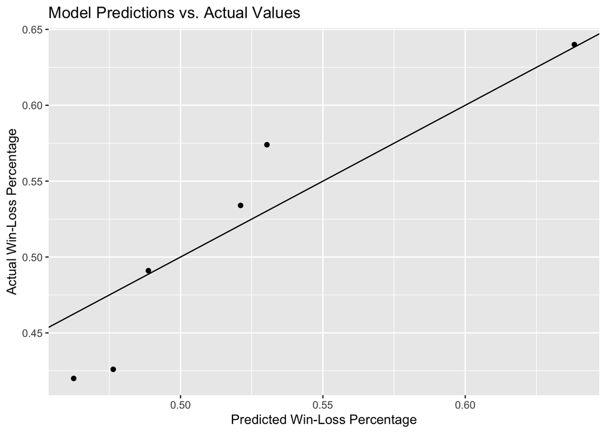

```r
ggplot(test, aes(x=predictions, y=win_loss_percentage)) + geom_point() + labs(x="Predicted Win-Loss Percentage",y="Actual Win-Loss Percentage",title="Model Predictions vs. Actual Values") + geom_abline()
```

**For this next model, we’ll explore if teams that hit more homeruns win more games.** The motivation for modeling this comes from the discussion that “small ball” is better for winning games. However, if we can see a significant connection between the number of homeruns a teams hits and the games they win, perhaps this discussion can be put to rest.

```r
homeruns <- tibble(date=game_data$date,
                   home=game_data$home,
                   away=game_data$away,
                   h_homeruns=game_data$h_homeruns,
                   v_homeruns=game_data$v_homeruns)


wins <- standings[match(teams$abb, standings$team), "wins"]
wins <- as.vector(wins$wins)

homeruns_model <- tibble(team=teams$abb,
                homeruns=0,
                wins=wins
                )

for (x in 1:length(homeruns$date)) {
  for (t in 1: length(homeruns_model$team)) {
    if (homeruns_model$team[t] == homeruns$away[x]) {
      homeruns_model$homeruns[t] <- homeruns_model$homeruns[t] + homeruns$v_homeruns[x]
    }
    if (homeruns_model$team[t] == homeruns$home[x]) {
      homeruns_model$homeruns[t] <- homeruns_model$homeruns[t] + homeruns$v_homeruns[x]
    }
  }
}
```

**Now we can create our model for this prediction**

```r
set.seed(1) # set the seed to yield consistent values in the data partition
h_model_selection <- createDataPartition(homeruns_model$wins, p=0.75, list = FALSE)

h_train <- homeruns_model[h_model_selection, ]
h_test <- homeruns_model[-h_model_selection, ]


h_train_model <- lm(data = h_train, formula=wins~homeruns)

h_predictions <- h_train_model %>%
  predict(h_test)
```

In summarizing our model, we can see that homeruns are a very bad predictor of a teams total wins in a season.

```r
summary(h_train_model)
```

```
##
## Call:
## lm(formula = wins ~ homeruns, data = h_train)
##
## Residuals:
##     Min      1Q  Median      3Q     Max
## -22.030  -6.856   1.565   6.146  17.497
##
## Coefficients:
##               Estimate Std. Error t value Pr(>|t|)
## (Intercept) 105.910096  20.007002   5.294  2.6e-05 ***
## homeruns     -0.009044   0.007050  -1.283    0.213
## ---
## Signif. codes:  0 '***' 0.001 '**' 0.01 '*' 0.05 '.' 0.1 ' ' 1
##
## Residual standard error: 9.909 on 22 degrees of freedom
## Multiple R-squared:  0.0696, Adjusted R-squared:  0.02731
## F-statistic: 1.646 on 1 and 22 DF,  p-value: 0.2129
```

```r
summary(h_predictions)
```

```
##    Min. 1st Qu.  Median    Mean 3rd Qu.    Max.
##   78.84   79.74   81.02   83.85   82.18  100.35
```

Additionally, in our plot here we can see that there is clearly no relationship between the number of homeruns that a team hits and the total wins that they have in a season.

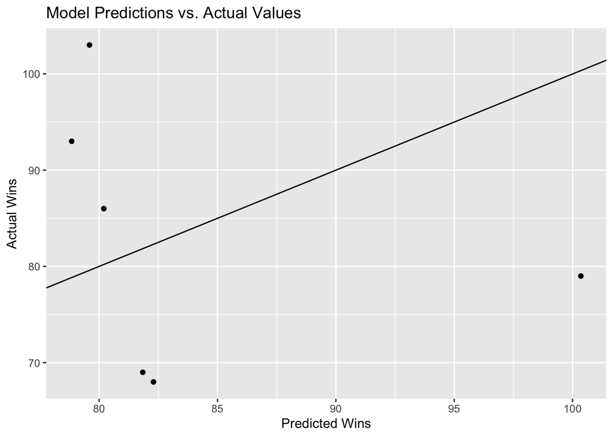

```r
ggplot(h_test, aes(x=h_predictions, y=wins)) + geom_point() + labs(x="Predicted Wins",y="Actual Wins",title="Model Predictions vs. Actual Values") + geom_abline()
```

```r
team_h_max <- homeruns_model[match(max(homeruns_model$homeruns), homeruns_model$homeruns), "team"]

standings[match(team_h_max, standings$team), c("rank", "team", "wins")]
```

| rank | team | wins |
| --- | --- | --- |
| 27 | CIN | 68 |

### Summary

With the models build here, I was able to find that a teams run-differential in the first month of the season is a good predictor of a teams win-loss percentage at the end of the season. Clearly the predicition that homeruns would be telling of a teams wins was a dead end though. Some possible limitations to this model would be teams have the potential to start very strong in the season and die off I suppose. There are a lot of factors that would contribute to a teams success in a season; however, in the model here it was pretty compelling to see the relationship between the run differential and the team’s win-loss percentage. Some ways to move forward with this model would be to train the model based on before and after the All-star break, by month, etc. Perhaps there are more significant time frames that would provide a more accurate result for a team’s win-loss percentage. Something that also came to my attention is that since the model is based on a domain of teams, there is not a ton of data. There are only 30 teams in the MLB, so in using this model, I am essentially seeing how well I can predict an individual team’s win-loss percentage based on other team’s run-differentials and their win-loss percentages. I am optimistic since the p-value was so extremely low; however, the scarcity of data in this model might not hold up. In order to solidify the validity of this model I would need to cross-validate it based on several other seasons. Keep in mind though, that even though the model set seems small, it is built from a transformation of very large datasets. So in its small appearance, there is actually a lot of collected data within it.